# Exponential growth

three lessons

2020-04-09

# The power of doubling

Some years ago I had the opportunity to teach about ecology and evolution in a master gardener program. I was thrilled and started thinking about all of the things I thought would be fun and useful to teach about. Then I learned that I had one evening, something like 2 or 3 hours. How on earth could I fit this all in? What was essential? Then, after some thought, I realized that if I could convey the power of exponential growth, and a bit about heritable variation, the rest followed. All these years later I still think that if I could convey one lesson it would be this: beware the awesome power of exponential growth.

In that first class with master gardeners, and in many classes with undergraduate and graduate students since, we explored the classic lesson about doubling on a chess board. The almost certainly apocryphal story goes something like this: The king/emperor/bigwig was so thrilled with the new game of chess that he reward its inventor with anything he might desire. The clever game-maker offered the modest suggestion that he receive a single grain of rice on the first square, two on the second square, four on the third and so on and so forth. In the end this amounted to more grain or rice than existed in the kingdom and so, depending on the version, the inventor is either made an adviser (or king in the version I was told) or executed. Nice story and all, but without some numbers it lacks a certain oomph. So, how much rice or wheat is that?

And yes, doubling and exponential growth are intimately linked

Or wheat, depending on the version.

https://en.wikipedia.org/wiki/Wheat_and_chessboard_problem

| Square ($x$) | Rice on square $x$ ($n$) | Total rice by square $x$ ($T$) |
| --- | --- | --- |
| 1 | 1 | 1 |
| 2 | 2 | 3 |
| 3 | 4 | 7 |
| 4 | 8 | 15 |
| 5 | 16 | 31 |
| 6 | 32 | 63 |
| 7 | 64 | 127 |
| 8 | 128 | 255 |
| 9 | 256 | 511 |
| 10 | 512 | 1023 |

Before we look at The Big Numbers that I’ve hinted at, let’s see if we can’t spot a pattern in how they grow (see the table above for the first ten squares). Perhaps you’ll recognize that the numbers on the squares are powers of two.

$$2^0 = 1\\
2^1 = 2\\
2^2 = 4\\
2^3 = 8$$

Following this pattern the amount on the 5th square is $2^{5-1}= 2^4 = 16$ and the amount on the 64th square is $2^{(64-1)} = 2^{63}$. In general for square $x$, the number of grains on the square is $n(x)=2^{x-1}$.

Note that if we started counting the first square as zero, as we would if we were tracking time instead of counting squares, this would simply be $n(x)=2^{x}$.

What about the *total* number of grains on square $x$, which we’ll call $T(x)$? We could just do the math and add those numbers up: $T(x)=2^0 + 2^1 + 2^2 + \dots + 2^{x-1}$. We could also write it more compactly using the summation sign, $\Sigma$: $T(x) = \sum_{i=1}^{i=n} 2^{i-1}$. But we can also cheat a bit if we notice the pattern. The total in the first two squares is $1+2=3$ and in the first three squares is $1+2+4=7$ and in the first four squares is $1+2+4+8=15$. These sums are *close* to the power of two (i.e., $2^2, 2^3, \text{ and}, 2^4$). Indeed, in each case they are just one below that power. The pattern is $T(x) = 2^x - 1$. So the total (cumulative) number of grains on the 64 squares of the chessboard given this little doubling game is $T_{64}=2^{64}-1$.

If we started counting with $x=0$ then this would be $T(x) = 2^{x+1} - 1$.

Now, how much are those?

$n_{64}=2^{64-1}=2^{63}$ = 9 223 372 036 854 775 808

$T_{64}=2^{64}-1=$ 18 446 744 073 709 551 616

Those are big numbers! Quintillions or, if you prefer, billions of billions! But quite honestly that doesn’t mean a lot to me. I tried Wolfram Alpha and while it wasn’t terribly helpful, it is sort of fun!

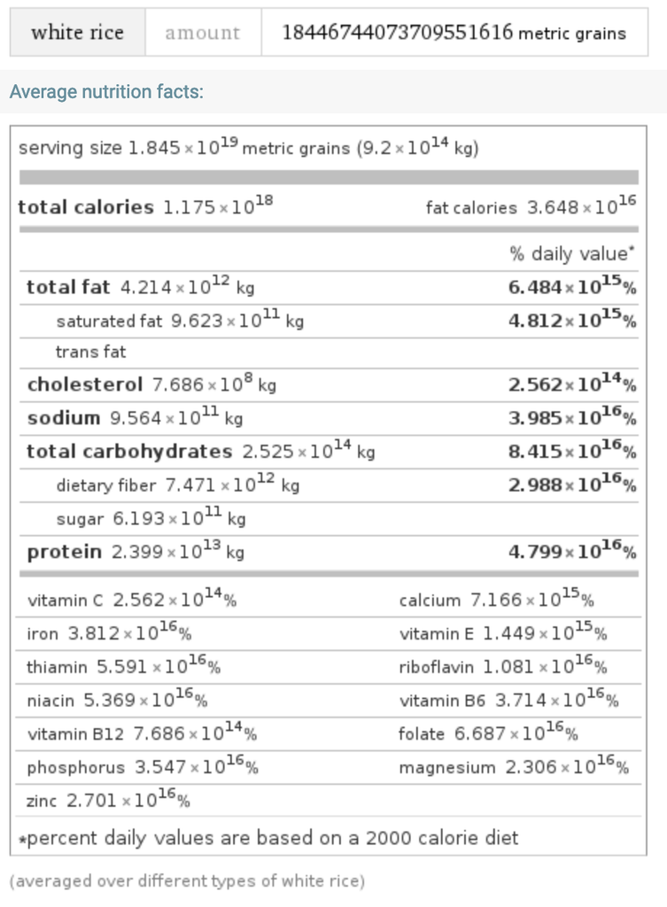

Nutritional value of a huge amount of rice. From [https://www.wolframalpha.com/input/?i=2^64+grains+of+rice](https://www.wolframalpha.com/input/?i=2%5E64+grains+of+rice)

Let’s try again. What is the total rice production in the world? Wolfram Alpha places it at 2.573 billion metric tons per year or $2.573 \times 10^9 \text{tons} \times 1000 \text{kg/ton} = 2.573 \times 10^{12} \text{kg}$. That’s a lot! But it still pales in comparison to the $9.2 \times 10^{14} \text{kg}$ that the chessboard rice is estimated to weigh (see the nutrition panel above). In other words, we produce several *hundred* times less rice in a year than would have been on that chess board if the king or emperor had been able to follow through on the deal. Zowie!

[https://www.wolframalpha.com/input/?i=2^64+grains+of+rice](https://www.wolframalpha.com/input/?i=2%5E64+grains+of+rice)

I am by no means the first to use this example or to try to provide some context to the numbers

Just search online for “exponential growth chess board” and you’ll find TED talks, YouTube videos, and even stock photos. One of my favorites is this one: https://makershare.com/projects/chess-board-rice-exponential-growth .

# Doubling processes can sneak up you

One classic question in math and ecology exams is the following: If a lily pad grows so that it doubles its size (or coverage of a pond) each day and it covers the whole pond on the 20th day, on what day was the pond half covered? Take a moment and think about it…

The answer is to work backwards. If the lily pad doubles each day, then moving backward in time it is halved each day. So the answer is day 19. The same is true for our chess board example and any other doubling process, although it may take more or less time than a day to double. For instance, if we were watching this lily grow on a pond, how much time would we have from when it covered $< 1\%$ of the pond to it covering the whole thing?

Well, on day 19 it covered half the pond, on day 18 it covered one-quarter of the pond (half of a half), on day 17 it covered one-eighth the pond (half of a half of a half), and so on. If $x$ is the time *before* some threshold (i.e., 100% coverage), such that $x$ is $0,-1,-2,...$, then the fraction of the pond covered at time $x$ is $n(x) = 2^x$. We find that when $x=-7$ less than $1\%$ of the surface area would be covered (precisely, $2^{-7} = 0.0078125$ or 0.78%). Think about that. If you were watching the lily grow, you wouldn’t see anything worrying for a long time. Only on day 14 would more than 1% of the surface area be covered. Why worry? But in just a few days, a few more rounds of doubling, this process would start to look rather out of control.

The fact that doubling processes only seem out of control later on has been called the “second half of the chessboard” in business, but it applies equally to many processes. For instance, biological invasions start with small numbers of individuals that are quite capable of doubling over some time interval and are often discovered too late, as the invasion is out of control. The same is true of epidemics. They start small, but if one person infects two others, it’s only nine “generations” of infection before that one infected person becomes more than a thousand and nineteen generations before there are more than a million!

https://en.wikipedia.org/wiki/Wheat_and_chessboard_problem

It can be hard to recognize how a doubling process might grow in the early days. Again, the initial numbers are small and seemingly innocuous, if not plain hard to detect. But also, most processes, at least biological processes are messy or stochastic. Does one infected person give rise to one new infection, or three? Those chance outcomes have a lot of influence early on in the process when the numbers are low, but average out later, when there are more people doing the infecting (or invasive, I don’t know, eels reproducing).

The doubling process with increasing amounts of chance or noise in the process. Each process was run three time. Notice that one of the three processes with the most noise fizzled out in generation three.

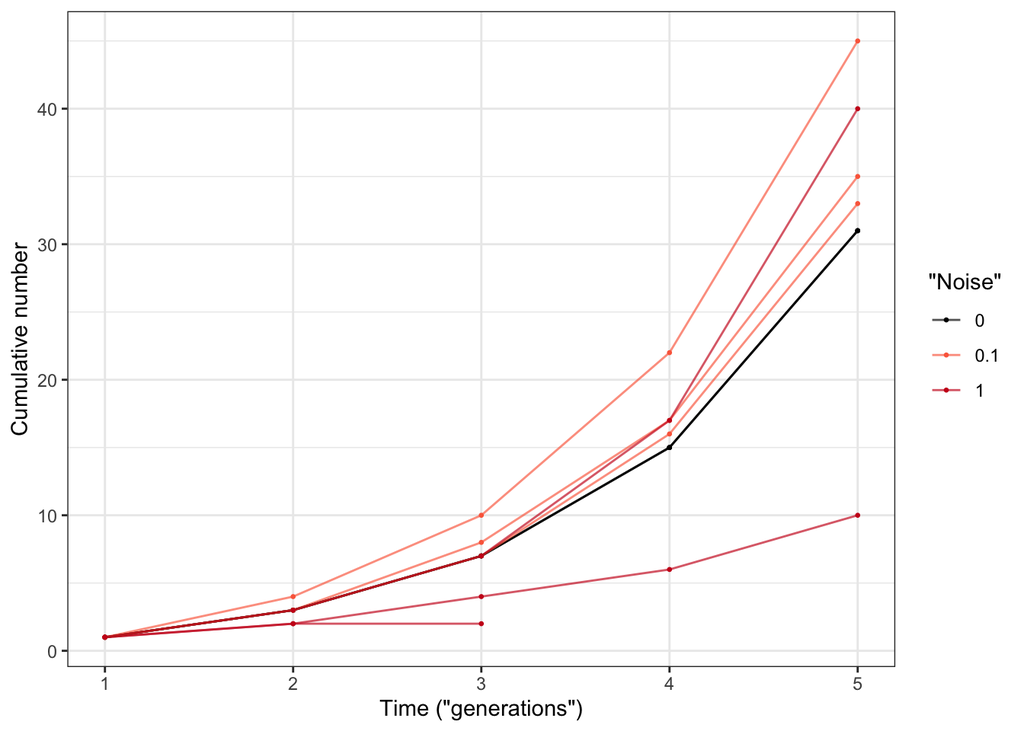

Given the noisiness due to randomness in real-world processes, it is often hard to know if something is growing rapidly or slowly, or even whether it might be exponential at all.

## Exponential growth more broadly

So far we have been dealing with processes where something doubles every time step. This is simply a special case of geometric growth (or decay), which is really just a discrete version of exponential growth (or decay). What does this mean? Let us first focus on the discrete cases.

There are many cases where growth happens in discrete steps. For instance, birds and amphibians in temperature habitats usually breed in the spring and so there is a pulse of reproduction. Similarly, your bank account might apply interest (or fees!) once a month. We might write an equation for the amount $n$ at time $t$ as,
$$N(t) = N_0 \times \lambda^t,$$
where $N_0$ is what you started with and $\lambda$ is the per time-step growth rate. If $\lambda = 1$ the amount never changes, but if $\lambda > 1$ the amount increases. And of course if $\lambda < 1$ then the amount decreases.

Although mortality can happen all year long.

Now you might wonder how this equation relates to our chess-doubling game above, where $n(x)=2^{x-1}$. They are actually identical if we set $t=x-1$, because above we started counting at square one instead of time zero, $N_0 = 1$ because there was one grain of rice on the first square, and $\lambda = 2$ because we doubled ever step. What this version of the equation makes clear is that we could play many versions of the game where instead of doubling each step ($\lambda = 2$), we triple ($\lambda = 3$) or increase by one-quarter ($\lambda = 1.25$) or shrink by half ($\lambda = 0.5$ or use any other rate of change. It is also important to note that even if we are not precisely doubling each step ($\lambda \neq 2$), so long as the amount grows, it will double, and then double again, and so on.

We can find the doubling time, which I will call $\tau$, given any (positive) value of $\lambda$ by recognizing that $N(\tau) = 2N_0$, taking the log of both sides, and then doing some re-arranging.
$$N(\tau) = 2N_0 = N_0 \times \lambda^\tau\\
2=\lambda^\tau\\
\log(2) = \log( \lambda^\tau ) = \tau \times \log(\lambda) \\
\tau = \frac{\log(2)}{\log(\lambda)}$$
So if $\lambda=2$ then the doubling time $\tau=1$ and if $\lambda = 1.5$ then $\tau = \log(2)/\log(1.5) = 1.7095$.

For many processes, from dividing bacteria to transmission of infections to the buying and selling of stocks, growth (or decline) does not happen in discrete steps, but rather everything happens all the time. In other words, it would be more accurate to think of time as continuous rather than discrete. The same logic applies, but the equation looks slightly different:
$$N(t) = N_0 \times e^{rt}.$$
In this exponential equation $e^r$ is equivalent to $\lambda$ in the geometric equation; we just need to keep in mind in this version the amount does not change when $r=0$ because $e^0 = 1$, it grows when $r>0$ and it shrinks when $r < 0$. Moreover, the doubling time is simply $\tau = \log(2)/\log(\lambda) = \log(2)/\log(e^r) = \log(2)/r$. The doubling time is one when $r=\log(2) = 0.693$.

The exponential equation is the solution to the differential equation $\frac{dN}{dt} = rN$, which highlights the fact that $r$ is the per capita growth rate.

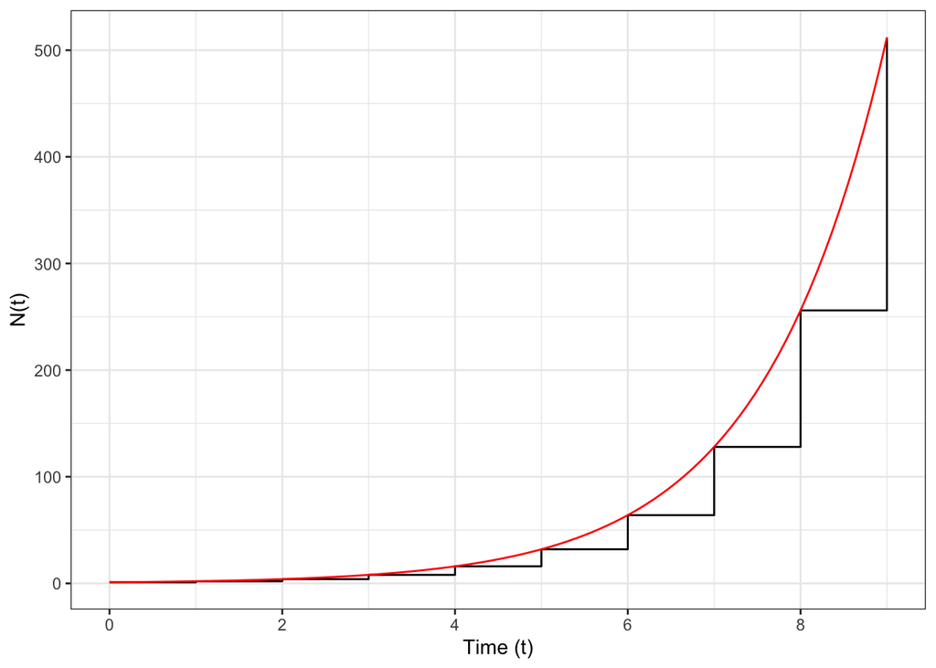

Geometric doubling (black line) occurs in discrete steps whereas exponential doubling (red line) is a continuous process.

If you want to ignore the math, just note that these two equations are equivalent and produce equivalent dynamics; only one takes time (or chess squares) in discrete steps and the other treats it as continuous. Most mathematically-inclined people favor the exponential equation because it has nicer properties that make it easier to work with.

# Exponential grow means a *constant* growth rate

In our examples so far, something (rice, lily pads, epidemics) double in every $\tau$ time steps or generation. This means that every individual (grain of rice, infected individual) yields two individuals in the next $\tau$ steps, always. It doesn’t matter how many there are or what else is happening there is *always* a doubling. This can be easier to see if we plot the data on a logarithmic scale.

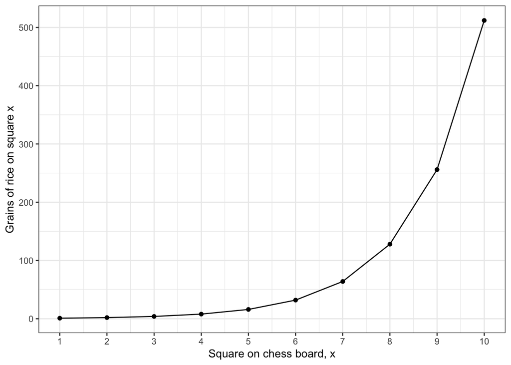

The first ten squares of the chess board on a linear y-axis

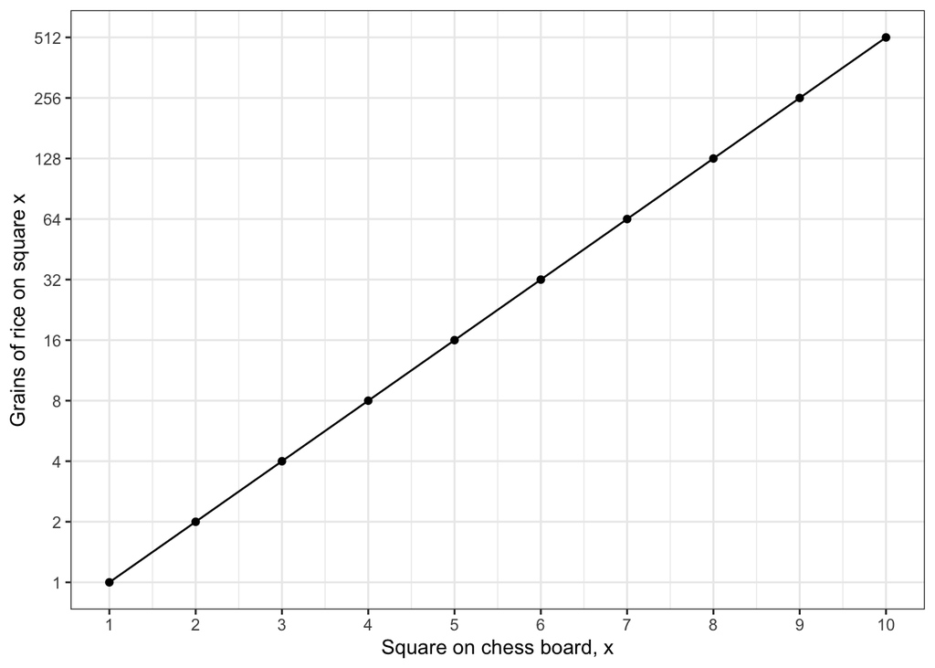

The first ten squares of the chess board on a log base 2 y-axis

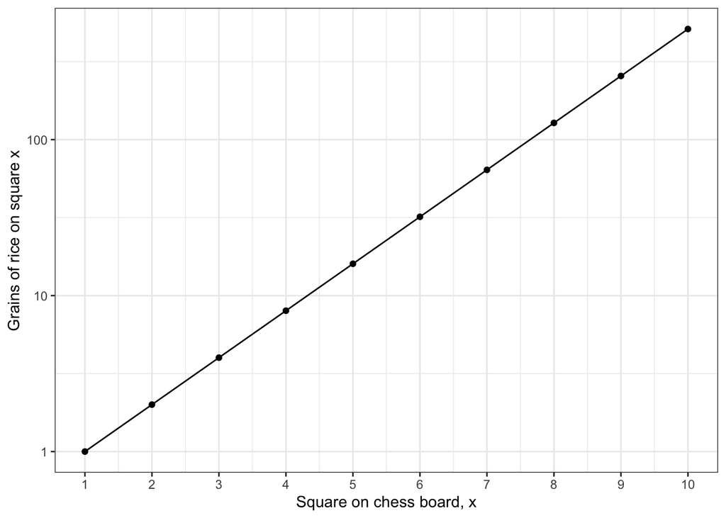

The first ten squares of the chess board on a log base 10 y-axis

What is important about a logarithmic scale is that there is a constant proportionality. On the second graph, with a log base 2 y-axis, the distance along the y axis between 2 and 4 is the same as between 16 and 32 or 512 and 1024; each represents a doubling of the number. On the third graph, with the more common log base 10 y-axis, the distance between 1 and 10 is the same as between 10 and 100; each represents a 10-fold increase.

If a process produces a straight line on a logarithmic scale, it means growth (or decline) is happening at a constant rate. We can see why with a bit of light math. Let us simply take the log of both sides of the geometric growth equation and simplify.
$$N(t) = N_0 \times \lambda^t \\
\log(N(t)) = \log(N_0 \times \lambda^t) \\
\log(N(t)) = \log(N_0) +\log(\lambda)\times t$$
Notice that this now takes the form of a straight line ($y=b+mx$) where $\log(N_0)$ is the intercept and $\log(\lambda)$ is the slope. The rate of increase (or decrease, if the slope is negative) is $\log(\lambda)$ every where along the x-axis; it does not change. On the log-base 2 graph this doubling produces a slope of one because $\log_2(2)=1$.

The math is even easier with the exponential equation,
$$\log(N(t)) = \log(N_0 \times e^{rt}) \\
\log(N(t)) = \log(N_0) +r \times t$$
and shows that the slope on a (natural) log scale is simply $r$. Setting aside the math, what is the point? It is simply that logarithmic scales linearize geometric or exponentially growing (or shrinking) processes.

It is also important to note that slightly different slopes, representing different growth rates, can have dramatic effects on the resulting amounts.

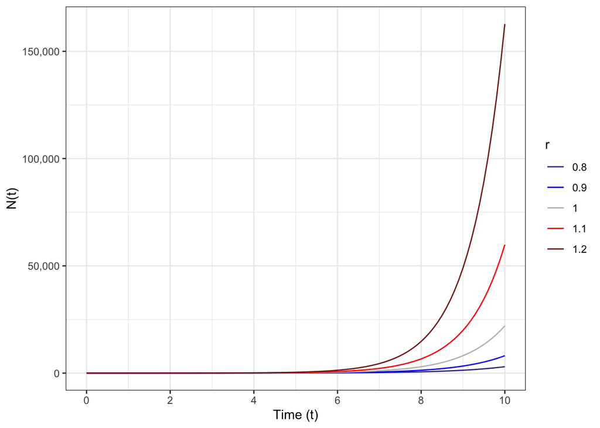

Exponential growth with a range of intrinsic growth rates, $r$ on a linear scale.

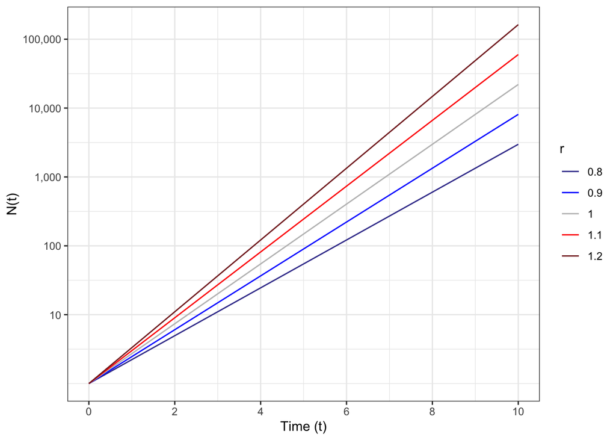

Exponential growth with a range of intrinsic growth rates, $r$ on a logarithmic scale.

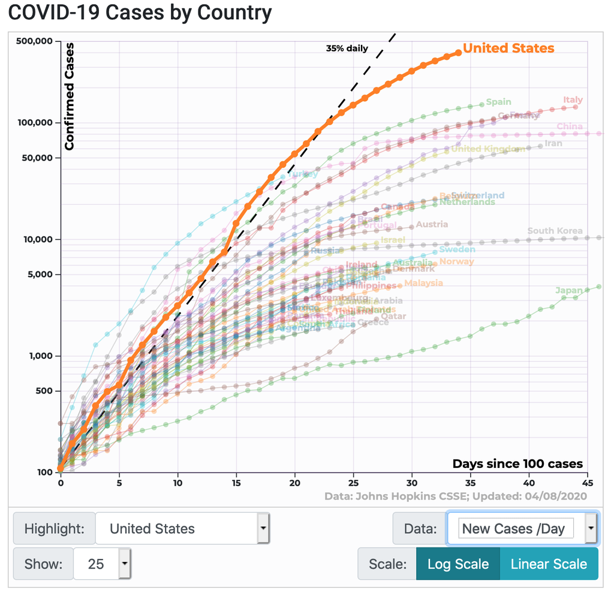

This also transfers to changes in slopes along a line. When we look at cases of COVID-19 (or resulting deaths)—as I have been obsessively doing for many weeks—we are interested in the slope as things go up, which indicates how rapidly the epidemic is growing. We are also looking and hoping for these lines to get shallower, bending flatter and flatter, meaning first that the rate at which the epidemics are growing is slowing, but eventually we hope they slope downward, meaning the epidemic is waning.